# STudy Group 7: Homework 3

## 3.3 Relationship Experience - Gender?

At the board meeting, someone raised the issue that there was indeed a substantial difference between male and female salaries, but that this was attributable to other reasons such as differences in experience. A questionnaire send out to the 50 executives in the sample reveals that the average experience of the men is approximately 21 years, whereas the women only have about 7 years experience on average (see table below).

```r
# Summary Statistics of salary by gender
favstats (experience ~ gender, data=omega)
```

```
##   gender min    Q1 median   Q3 max  mean    sd  n missing
## 1 female   0  0.25    3.0 14.0  29  7.38  8.51 26       0
## 2   male   1 15.75   19.5 31.2  44 21.12 10.92 24       0
```

```r
t.test(experience~gender, data = omega) #find t-stat, p-value
```

```
##
##  Welch Two Sample t-test
##
## data:  experience by gender
## t = -5, df = 43, p-value = 1e-05
## alternative hypothesis: true difference in means between group female and group male is not equal to 0
## 95 percent confidence interval:
##  -19.35  -8.13
## sample estimates:
## mean in group female   mean in group male
##                 7.38                21.12
```

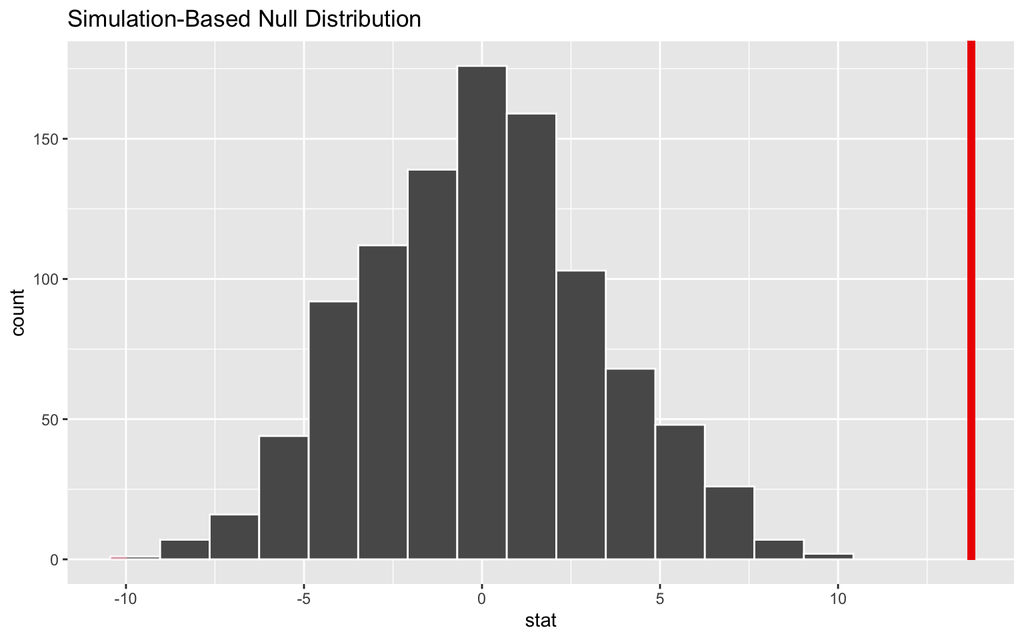

```r
mean_dif <- omega %>% specify(experience~gender) %>% calculate(stat = "diff in means", order = c("male","female"))

#simulating a null world using infer()
set.seed(1234)
ratings_in_null_world <- omega %>%
  specify(experience~gender) %>% # we want to look at ratings of directors
  hypothesize(null = "independence") %>%  # hypothesize that the difference is 0
  generate(reps=1000, type="permute") %>% # create a bunch of simulated samples
  calculate(stat="diff in means", order = c("male","female")) # find difference in means of each sample.

#ratings_in_null_world visualize, with shaded p value
ratings_in_null_world %>% visualize() +
  shade_p_value(obs_stat = mean_dif , direction = "two-sided")
```

```r
 # finding p-value of simulated distribution
p_value <- ratings_in_null_world%>%
  get_p_value(obs_stat = mean_dif, direction = "two-sided")
p_value
```

```
## # A tibble: 1 × 1
##   p_value
##     <dbl>
## 1       0
```

Based on this evidence, can you conclude that there is a significant difference between the experience of the male and female executives? Perform similar analyses as in the previous section. Does your conclusion validate or endanger your conclusion about the difference in male and female salaries?

*Again, there are three ways to tell whether there is a statistically significant difference in the experience of male and female executives.

- Firstly, the confidence interval does not contain zero, thus we reject the null hypothesis and there is a significant difference in experience of the male and female executives.
- t-statistic is larger than 2, thus we reject the null-hypothesis.
- p-value is smaller than 5%, thus we reject the null-hypothesis.

Our conclusion endangers the conclusion about the difference in male and female salaries. This is because the difference in experience is indicating that there are other factors than gender itself that can explain the difference in salary. The conclusion that there is gender discrimination in salary may be violated. Thus, further investigation is required to confirm whether other factors can also affect the difference in salaries.

## 3.4 Relationship Salary - Experience ?

Someone at the meeting argues that clearly, a more thorough analysis of the relationship between salary and experience is required before any conclusion can be drawn about whether there is any gender-based salary discrimination in the company.

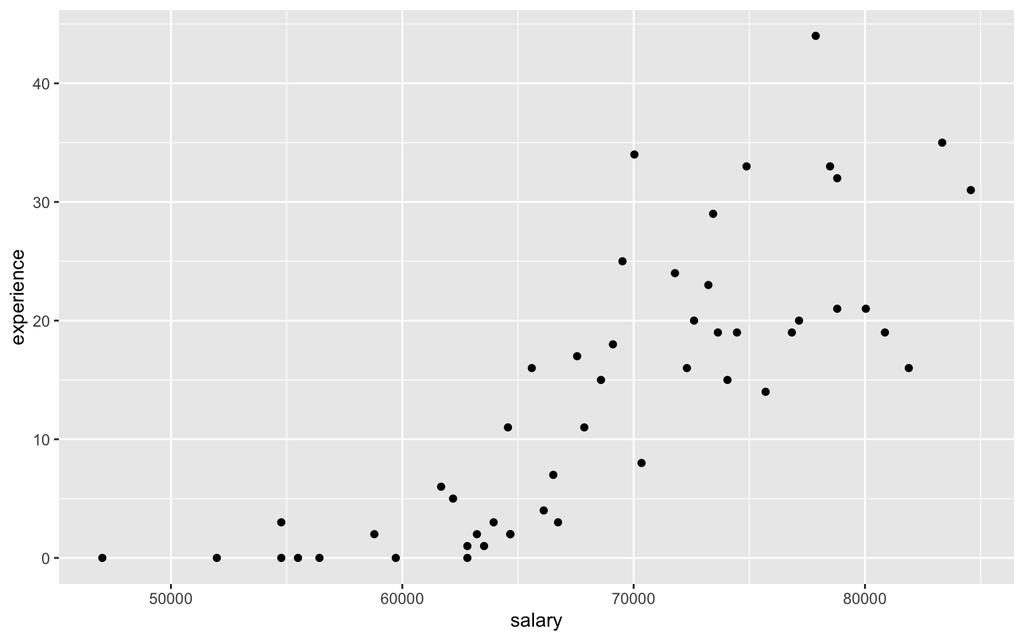

```r
ggplot(omega, aes(salary, experience)) + geom_point()
```

## 3.5 Check correlations between the data

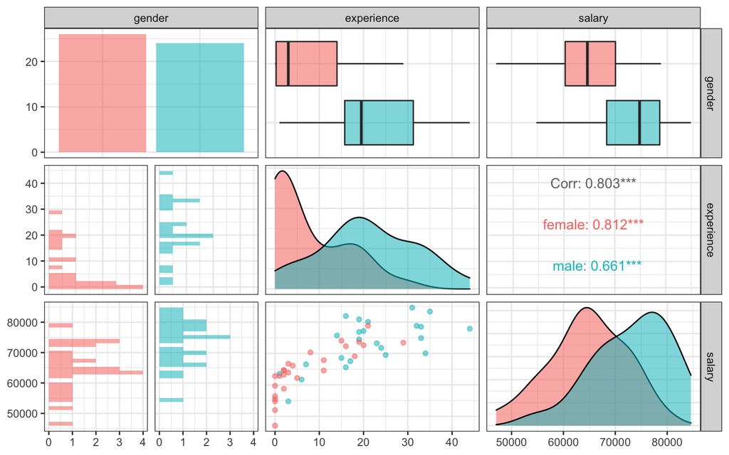

```r
omega %>%
  select(gender, experience, salary) %>% #order variables they will appear in ggpairs()
  ggpairs(aes(colour=gender, alpha = 0.3))+
  theme_bw()
```

Salary vs Experience scatterplot: We can see that there is a positive correlation between experience and salary for both genders. The more years of work experience, the higher the salaries. The correlation coefficients (approximately 0.803 for both, 0.812 for females and 0.661 for males) calculated above confirm the observations we drew from looking at the scatterplot.

From the boxplots above we can also easily tell that the median work experience is much less for female executives and that female median salary is also smaller, but to a lesser extent. From the density graphs, we can see that the distribution of work experience for female is concentrated on the lower ends.

The above observations are suggesting that the ‘number of years worked’ is very likely to be a valid underlying factor to explain the gender salary gap. However, we cannot totally eliminate gender discrimination as a factor for gender pay gap. For instance, it is worth looking into whether there are gender related issues that prevent female executives to attain more work experience in general?

It would also be interesting to look at the age differences in female and male executives because that could be the underlying reason why there are significant differences in their average work experience.

# 4 Challenge 1: Brexit plot

```r
#load brexit data
brexit <- read_csv(here::here("data", "brexit_results.csv"))
skim(brexit)
```

Data summary

| Name | brexit |
| --- | --- |
| Number of rows | 632 |
| Number of columns | 11 |
| _______________________ |  |
| Column type frequency: |  |
| character | 1 |
| numeric | 10 |
| ________________________ |  |
| Group variables | None |

**Variable type: character**

| skim_variable | n_missing | complete_rate | min | max | empty | n_unique | whitespace |
| --- | --- | --- | --- | --- | --- | --- | --- |
| Seat | 0 | 1 | 4 | 43 | 0 | 632 | 0 |

**Variable type: numeric**

| skim_variable | n_missing | complete_rate | mean | sd | p0 | p25 | p50 | p75 | p100 | hist |
| --- | --- | --- | --- | --- | --- | --- | --- | --- | --- | --- |
| con_2015 | 0 | 1.00 | 36.60 | 16.22 | 0.00 | 22.09 | 40.85 | 50.84 | 65.88 | ▂▅▃▇▅ |
| lab_2015 | 0 | 1.00 | 32.30 | 16.54 | 0.00 | 17.67 | 31.20 | 44.37 | 81.30 | ▆▇▇▅▁ |
| ld_2015 | 0 | 1.00 | 7.81 | 8.36 | 0.00 | 2.97 | 4.58 | 8.57 | 51.49 | ▇▁▁▁▁ |
| ukip_2015 | 0 | 1.00 | 13.10 | 6.47 | 0.00 | 9.19 | 13.73 | 17.11 | 44.43 | ▃▇▃▁▁ |
| leave_share | 0 | 1.00 | 52.06 | 11.44 | 20.48 | 45.33 | 53.69 | 60.15 | 75.65 | ▂▂▆▇▂ |
| born_in_uk | 0 | 1.00 | 88.15 | 11.29 | 40.73 | 86.42 | 92.48 | 95.42 | 98.02 | ▁▁▁▂▇ |
| male | 0 | 1.00 | 49.07 | 0.80 | 46.86 | 48.61 | 49.02 | 49.43 | 53.05 | ▁▇▃▁▁ |
| unemployed | 0 | 1.00 | 4.37 | 1.42 | 1.84 | 3.23 | 4.19 | 5.21 | 9.53 | ▆▇▅▂▁ |
| degree | 59 | 0.91 | 16.71 | 8.36 | 5.10 | 10.79 | 14.69 | 19.59 | 51.10 | ▇▆▂▁▁ |
| age_18to24 | 0 | 1.00 | 9.29 | 3.59 | 5.73 | 7.30 | 8.28 | 9.60 | 32.68 | ▇▁▁▁▁ |

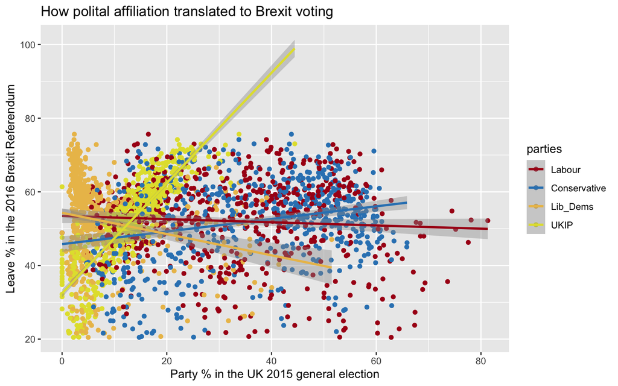

```r
#knitr::include_graphics(here::here("images", "brexit.png"), error = FALSE)
#transferring the data into long format instead of wide
brexit <- brexit %>% rename(Conservative=con_2015, Labour = lab_2015, Lib_Dems = ld_2015, UKIP = ukip_2015)

brexit2<- brexit %>% pivot_longer(cols=c('Conservative', 'Labour','Lib_Dems', 'UKIP'),
                    names_to='parties',
                    values_to='parties_share')
#plot the data
ggplot(brexit2, aes(x =parties_share, y=leave_share, color = parties))+geom_point()+geom_smooth(method=lm)+
  scale_color_manual(breaks = c('Labour','Conservative', 'Lib_Dems', 'UKIP'),
                        values=c("#aa1619", "#3284bf","#ebbf58","#e2e039"))+
  labs(x = "Party % in the UK 2015 general election")+
  labs( y = "Leave % in the 2016 Brexit Referendum")+
  ggtitle("How polital affiliation translated to Brexit voting")
```

# 5 Challenge 2:GDP components over time and among countries

At the risk of oversimplifying things, the main components of gross domestic product, GDP are personal consumption (C), business investment (I), government spending (G) and net exports (exports - imports). You can read more about GDP and the different approaches in calculating at the [Wikipedia GDP page](https://en.wikipedia.org/wiki/Gross_domestic_product).

The GDP data we will look at is from the [United Nations’ National Accounts Main Aggregates Database](https://unstats.un.org/unsd/snaama/Downloads), which contains estimates of total GDP and its components for all countries from 1970 to today. We will look at how GDP and its components have changed over time, and compare different countries and how much each component contributes to that country’s GDP. The file we will work with is [GDP and its breakdown at constant 2010 prices in US Dollars](http://unstats.un.org/unsd/amaapi/api/file/6) and it has already been saved in the Data directory. Have a look at the Excel file to see how it is structured and organised

```r
UN_GDP_data  <-  read_excel(here::here("data", "Download-GDPconstant-USD-countries.xls"), # Excel filename
                sheet="Download-GDPconstant-USD-countr", # Sheet name
                skip=2) # Number of rows to skip
```

```r
tidy_GDP_data  <-  UN_GDP_data%>%
  pivot_longer(cols = 4:51, names_to='years',values_to='components_GDP') %>%
  mutate(components_GDP_billions =components_GDP/(1000000000) )

glimpse(tidy_GDP_data)
```

```
## Rows: 176,880
## Columns: 6
## $ CountryID               <dbl> 4, 4, 4, 4, 4, 4, 4, 4, 4, 4, 4, 4, 4, 4, 4, 4…
## $ Country                 <chr> "Afghanistan", "Afghanistan", "Afghanistan", "…
## $ IndicatorName           <chr> "Final consumption expenditure", "Final consum…
## $ years                   <chr> "1970", "1971", "1972", "1973", "1974", "1975"…
## $ components_GDP          <dbl> 5.56e+09, 5.33e+09, 5.20e+09, 5.75e+09, 6.15e+…
## $ components_GDP_billions <dbl> 5.56, 5.33, 5.20, 5.75, 6.15, 6.32, 6.37, 6.90…
```

```r
# Let us compare GDP components for these 3 countries
country_list <- c("United States","India", "Germany")
```

## 5.1 GDP components over time

```r
GDPdata2 <- tidy_GDP_data
old_name<- c("Gross capital formation",
             "Exports of goods and services",
             "General government final consumption expenditure",
             "Household consumption expenditure (including Non-profit institutions serving households)",
             "Imports of goods and services")


new_name<- c( "Gross capital formation",
              "Exports",
              "Government expenditure",
              "Household expenditure",
              "Imports")


names(new_name) <-old_name
GDPdata2$IndicatorName <- new_name[GDPdata2$IndicatorName]
GDPdata2 <- GDPdata2 %>%
  na.omit(IndicatorName)
```

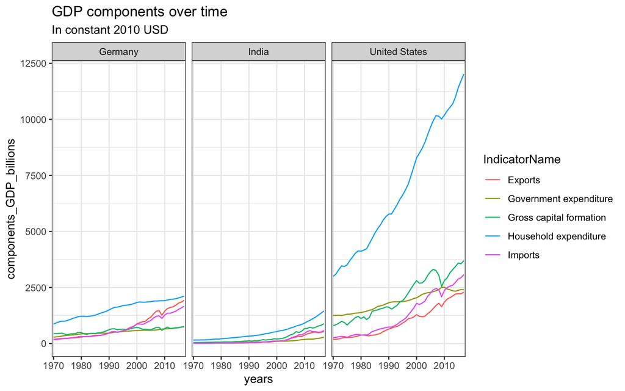

```r
GDP_components_over_time <- GDPdata2 %>% filter(Country %in% country_list) %>% group_by(IndicatorName)
#GDP_components_over_time <- GDP_components_over_time %>% filter(IndicatorName == 'Household expenditure')

ggplot(GDP_components_over_time,
       aes(x=years,y=components_GDP_billions,colour = IndicatorName))+
  geom_line(aes(group=IndicatorName))+
  facet_wrap(~Country) +
  labs(title="GDP components over time", subtitle="In constant 2010 USD") +
  theme(axis.text=element_text(size=3))+
  scale_x_discrete(breaks = c(1970,1980,1990,2000,2010,2020))+
  theme_bw()
```

```r
#+theme_minimal()
#+xlim(1970,2020)
```

## 5.2 GDP and its breakdown at constant 2010 prices in US dollars

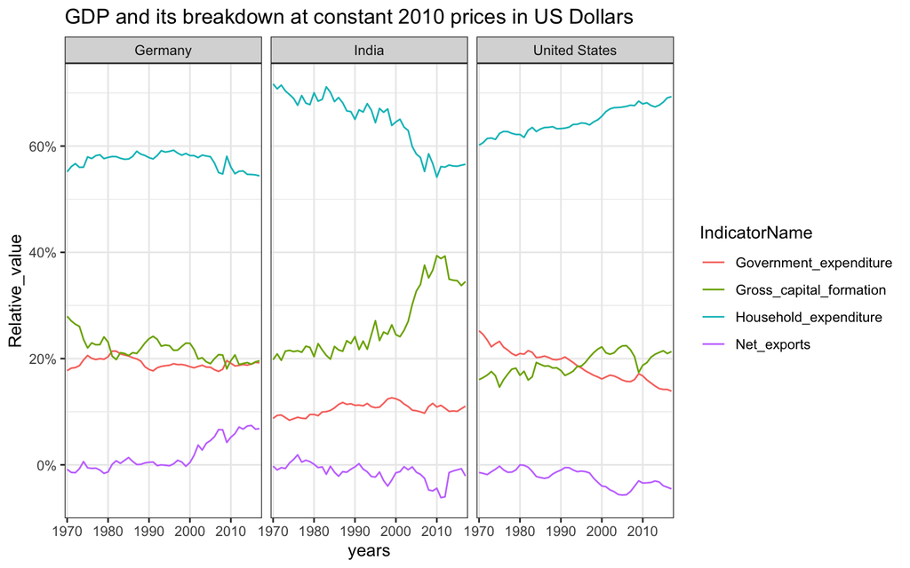

```r
GDP_components_over_time2 <- GDP_components_over_time %>%
  select(-components_GDP) %>%
  pivot_wider(names_from=IndicatorName,
              values_from = components_GDP_billions)

colnames(GDP_components_over_time2) <-c("CountryID","Country","years","Household_expenditure","Government_expenditure","Gross_capital_formation","Exports","Imports")

GDP_components_over_time3 <- GDP_components_over_time2 %>%
  mutate(Net_exports=Exports-Imports,GDP_total=(Household_expenditure+Government_expenditure+Gross_capital_formation+Exports-Imports)) %>%
  select(-Exports,-Imports) %>%
  pivot_longer(4:7,names_to ="IndicatorName",values_to="GDP_components_billions") %>%
  mutate(Relative_value=GDP_components_billions/GDP_total)

ggplot(GDP_components_over_time3,
       aes(x=years,y=Relative_value, colour=IndicatorName, group=IndicatorName)) +
  geom_line() +
  facet_wrap(~Country) +
  scale_x_discrete(breaks = c(1970,1980,1990,2000,2010,2020)) +
  scale_y_continuous(labels=scales::percent) +
  theme_bw() +
  labs(title = "GDP and its breakdown at constant 2010 prices in US Dollars", x="years")
```

> What is this last chart telling you? Can you explain in a couple of paragraphs the different dynamic among these three countries?

The last chart shows us a clear breakdown of GDP from 1970 to 2020 spread across 4 key categories - Government Expenses, Gross Capital Formation, House Expenses and Net Exports.

# 6 Details

- Who did you collaborate with: Lejla Kajevic, Francesco Nicolì, Zitong Hu, Rufei Wang, Siddharth Gulati